# King Sejong’s National Poll on Tax Reform

coop711

2015년 3월 29일

## Data Management

- Original data came from intenet version of Sejong silok, summarized by Oh, Ki-Soo.

```r
sejong.poll<-read.table("../data/sejong_poll.txt",header=TRUE,sep="")
str(sejong.poll)
```

```
## 'data.frame':    44 obs. of  4 variables:
##  $ counts: int  21 194 259 393 443 117 1123 71 29 5 ...
##  $ vote  : Factor w/ 2 levels "no","yes": 2 1 2 1 2 1 2 1 2 1 ...
##  $ class : Factor w/ 5 levels "chief","high",..: 2 2 4 4 5 5 3 3 1 1 ...
##  $ region: Factor w/ 10 levels "chungcheong",..: 9 9 9 9 9 9 10 10 2 2 ...
```

```r
sejong.poll
```

```
##    counts vote         class      region
## 1      21  yes          high       Seoul
## 2     194   no          high       Seoul
## 3     259  yes third.current       Seoul
## 4     393   no third.current       Seoul
## 5     443  yes      third.ex       Seoul
## 6     117   no      third.ex       Seoul
## 7    1123  yes      ordinary        yuhu
## 8      71   no      ordinary        yuhu
## 9      29  yes         chief     gyunggi
## 10      5   no         chief     gyunggi
## 11  17076  yes      ordinary     gyunggi
## 12    236   no      ordinary     gyunggi
## 13      1   no          high     pyungan
## 14      6  yes         chief     pyungan
```

[output cut: 30 more lines]

- We need vote, class, region as factors. If you leave them as chr, it will be coerced to factor when you tabulate it according to alphabetical order, which is not what you want. So, use factor() to convert them. First, make a working copy vesion of sejong.poll

```r
sejong.poll.2<-sejong.poll
sejong.poll.2$vote<-factor(sejong.poll.2$vote, levels=c("yes","no"), labels=c("yes","no"))
str(sejong.poll.2)
```

```
## 'data.frame':    44 obs. of  4 variables:
##  $ counts: int  21 194 259 393 443 117 1123 71 29 5 ...
##  $ vote  : Factor w/ 2 levels "yes","no": 1 2 1 2 1 2 1 2 1 2 ...
##  $ class : Factor w/ 5 levels "chief","high",..: 2 2 4 4 5 5 3 3 1 1 ...
##  $ region: Factor w/ 10 levels "chungcheong",..: 9 9 9 9 9 9 10 10 2 2 ...
```

- You can check that “labels=” is not necessary if same as levels. Continue with class and region.

```r
sejong.poll.2$class<-factor(sejong.poll.2$class, levels=c("high","third.current", "third.ex", "chief", "ordinary"), labels=c("High","3rd.current", "3rd.former", "Chief", "Commons"))
sejong.poll.2$region<-factor(sejong.poll.2$region, levels=c("Seoul","yuhu", "gyunggi", "pyungan", "hwanghae", "chungcheong", "kangwon", "hamgil", "gyungsang", "jeolla"), labels=c("Seoul","Yuhu", "Gyunggi", "Pyungan", "Hwanghae", "Chungcheong", "Kangwon", "Hamgil", "Gyungsang", "Jeolla"))
str(sejong.poll.2)
```

```
## 'data.frame':    44 obs. of  4 variables:
##  $ counts: int  21 194 259 393 443 117 1123 71 29 5 ...
##  $ vote  : Factor w/ 2 levels "yes","no": 1 2 1 2 1 2 1 2 1 2 ...
##  $ class : Factor w/ 5 levels "High","3rd.current",..: 1 1 2 2 3 3 5 5 4 4 ...
##  $ region: Factor w/ 10 levels "Seoul","Yuhu",..: 1 1 1 1 1 1 2 2 3 3 ...
```

- We add color for the vote.

```r
sejong.poll.2$color[sejong.poll.2$vote=="yes"]<-"cyan"
sejong.poll.2$color[sejong.poll.2$vote=="no"]<-"red"
# sejong.poll.2$color <- factor(sejong.poll.2$color, levels=c("cyan", "red"))
```

- Check the total vote with xtabs()

```r
options(digits=3)
xtabs(counts~vote, data=sejong.poll.2)
```

```
## vote
##   yes    no
## 98657 74149
```

```r
with(sejong.poll.2, tapply(counts, vote, sum))
```

```
##   yes    no
## 98657 74149
```

```r
prop.table(xtabs(counts~vote, data=sejong.poll.2))
```

```
## vote
##   yes    no
## 0.571 0.429
```

- We can check the color. Coordinates of text() are found by locator(2). Try!

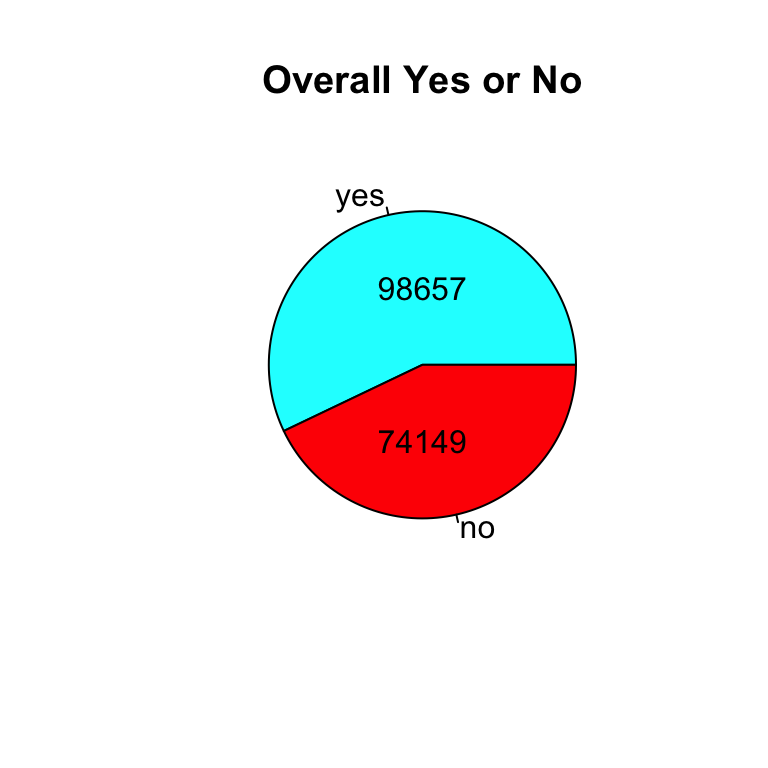

```r
pie(xtabs(counts~vote, data=sejong.poll.2), col=c("cyan", "red"))
title(main="Overall Yes or No")
text(x=0, y=c(0.4,-0.4), labels=c("98657", "74149"))
```

- Vote by class

```r
xtabs(counts~vote+class, data=sejong.poll.2)
```

```
##      class
## vote   High 3rd.current 3rd.former Chief Commons
##   yes    21         259        443   192   97742
##   no    200         393        117   135   73304
```

```r
with(sejong.poll.2, tapply(counts, list(vote = vote, class = class), sum))
```

```
##      class
## vote  High 3rd.current 3rd.former Chief Commons
##   yes   21         259        443   192   97742
##   no   200         393        117   135   73304
```

- We need to analyse Commons separately.

```r
sejong.poll.2$class.2<-factor(ifelse(sejong.poll.2$class=="Commons", "Commons", "Bureaus"))
```

- Compare the votes by class.2, (Bureaucrats vs Commons)

```r
xtabs(counts~vote+class.2, data=sejong.poll.2)
```

```
##      class.2
## vote  Bureaus Commons
##   yes     915   97742
##   no      845   73304
```

```r
with(sejong.poll.2, tapply(counts, list(vote = vote, class = class.2), sum))
```

```
##      class
## vote  Bureaus Commons
##   yes     915   97742
##   no      845   73304
```

- Add subtotals to the margins,

```r
addmargins(xtabs(counts~vote+class.2, data=sejong.poll.2))
```

```
##      class.2
## vote  Bureaus Commons    Sum
##   yes     915   97742  98657
##   no      845   73304  74149
##   Sum    1760  171046 172806
```

- Compute the marginal proportions. Note the use of digits=3.

```r
prop.table(xtabs(counts~vote+class.2, data=sejong.poll.2), margin=2)
```

```
##      class.2
## vote  Bureaus Commons
##   yes   0.520   0.571
##   no    0.480   0.429
```

- Pie charts for Bureacrats by vote and Commons by vote.

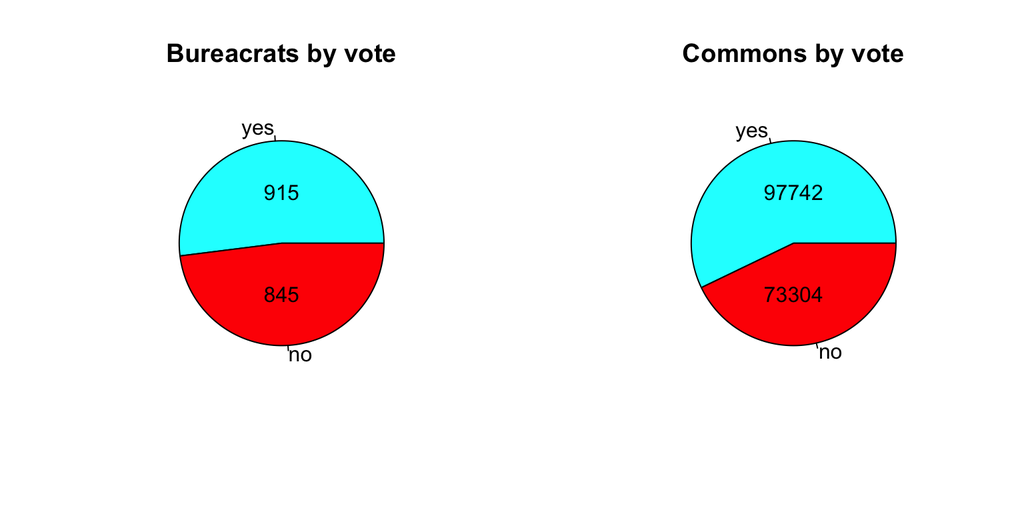

```r
attach(sejong.poll.2)
par(mfrow=c(1,2))
pie(xtabs(counts~vote+class.2, data=sejong.poll.2[class.2=="Bureaus",], drop=T), labels=c("yes", "no"), col=c("cyan", "red"))
title(main="Bureacrats by vote")
text(x=0, y=c(0.4,-0.4), labels=c("915", "845"))
pie(xtabs(counts~vote+class.2, data=sejong.poll.2[class.2=="Commons",], drop=T), labels=c("yes", "no"), col=c("cyan", "red"))
title(main="Commons by vote")
text(x=0, y=c(0.4,-0.4), labels=c("97742", "73304"))
```

```r
par(mfrow=c(1,1))
```

- Count the vote by region class.2 wise.

```r
xtabs(counts~vote+region, data=sejong.poll.2[class.2=="Bureaus",], drop=T)
```

```
##      region
## vote  Seoul Gyunggi Pyungan Hwanghae Chungcheong Kangwon Hamgil Gyungsang
##   yes   723      29       6       17          35       5      3        55
##   no    704       5      36       17          28      10     15        16
##      region
## vote  Jeolla
##   yes     42
##   no      14
```

```r
xtabs(counts~vote+region, data=sejong.poll.2[class.2=="Commons",], drop=T)
```

```
##      region
## vote   Yuhu Gyunggi Pyungan Hwanghae Chungcheong Kangwon Hamgil Gyungsang
##   yes  1123   17076    1326     4454        6982     939     75     36262
##   no     71     236   28474    15601       14013    6888   7387       377
##      region
## vote  Jeolla
##   yes  29505
##   no     257
```

```r
xtabs(counts~vote+region+class.2, data=sejong.poll.2, drop=T)
```

```
## , , class.2 = Bureaus
##
##      region
## vote  Seoul  Yuhu Gyunggi Pyungan Hwanghae Chungcheong Kangwon Hamgil
##   yes   723     0      29       6       17          35       5      3
##   no    704     0       5      36       17          28      10     15
##      region
## vote  Gyungsang Jeolla
##   yes        55     42
##   no         16     14
##
## , , class.2 = Commons
##
##      region
## vote  Seoul  Yuhu Gyunggi Pyungan Hwanghae Chungcheong Kangwon Hamgil
##   yes     0  1123   17076    1326     4454        6982     939     75
##   no      0    71     236   28474    15601       14013    6888   7387
##      region
## vote  Gyungsang Jeolla
##   yes     36262  29505
##   no        377    257
```

```r
(sejong.poll.2.bureaus <- subset(sejong.poll.2, class.2 == "Bureaus"))
```

```
##    counts vote       class      region color class.2
## 1      21  yes        High       Seoul  cyan Bureaus
## 2     194   no        High       Seoul   red Bureaus
## 3     259  yes 3rd.current       Seoul  cyan Bureaus
## 4     393   no 3rd.current       Seoul   red Bureaus
## 5     443  yes  3rd.former       Seoul  cyan Bureaus
## 6     117   no  3rd.former       Seoul   red Bureaus
## 9      29  yes       Chief     Gyunggi  cyan Bureaus
## 10      5   no       Chief     Gyunggi   red Bureaus
## 13      1   no        High     Pyungan   red Bureaus
## 14      6  yes       Chief     Pyungan  cyan Bureaus
## 15     35   no       Chief     Pyungan   red Bureaus
## 18     17  yes       Chief    Hwanghae  cyan Bureaus
## 19     17   no       Chief    Hwanghae   red Bureaus
## 22      2   no        High Chungcheong   red Bureaus
## 23     35  yes       Chief Chungcheong  cyan Bureaus
## 24     26   no       Chief Chungcheong   red Bureaus
## 27      5  yes       Chief     Kangwon  cyan Bureaus
## 28     10   no       Chief     Kangwon   red Bureaus
## 31      1   no        High      Hamgil   red Bureaus
## 32      3  yes       Chief      Hamgil  cyan Bureaus
## 33     14   no       Chief      Hamgil   red Bureaus
## 36     55  yes       Chief   Gyungsang  cyan Bureaus
## 37     16   no       Chief   Gyungsang   red Bureaus
## 40      2   no        High      Jeolla   red Bureaus
## 41     42  yes       Chief      Jeolla  cyan Bureaus
## 42     12   no       Chief      Jeolla   red Bureaus
```

```r
(sejong.poll.2.commons <- subset(sejong.poll.2, class.2 == "Commons"))
```

```
##    counts vote   class      region color class.2
## 7    1123  yes Commons        Yuhu  cyan Commons
## 8      71   no Commons        Yuhu   red Commons
## 11  17076  yes Commons     Gyunggi  cyan Commons
## 12    236   no Commons     Gyunggi   red Commons
## 16   1326  yes Commons     Pyungan  cyan Commons
## 17  28474   no Commons     Pyungan   red Commons
## 20   4454  yes Commons    Hwanghae  cyan Commons
## 21  15601   no Commons    Hwanghae   red Commons
## 25   6982  yes Commons Chungcheong  cyan Commons
## 26  14013   no Commons Chungcheong   red Commons
## 29    939  yes Commons     Kangwon  cyan Commons
## 30   6888   no Commons     Kangwon   red Commons
## 34     75  yes Commons      Hamgil  cyan Commons
## 35   7387   no Commons      Hamgil   red Commons
## 38  36262  yes Commons   Gyungsang  cyan Commons
## 39    377   no Commons   Gyungsang   red Commons
## 43  29505  yes Commons      Jeolla  cyan Commons
## 44    257   no Commons      Jeolla   red Commons
```

- Seoul has three times more Bureaucrats than other regions, so analyse further.

```r
(sejong.poll.2.seoul <- subset(sejong.poll.2, region == "Seoul"))
```

```
##   counts vote       class region color class.2
## 1     21  yes        High  Seoul  cyan Bureaus
## 2    194   no        High  Seoul   red Bureaus
## 3    259  yes 3rd.current  Seoul  cyan Bureaus
## 4    393   no 3rd.current  Seoul   red Bureaus
## 5    443  yes  3rd.former  Seoul  cyan Bureaus
## 6    117   no  3rd.former  Seoul   red Bureaus
```

```r
# xtabs(counts~vote+class, data=sejong.poll.2[region=="Seoul",], drop=T)
xtabs(counts~vote+class, data=sejong.poll.2.seoul, drop=TRUE)
```

```
##      class
## vote  High 3rd.current 3rd.former
##   yes   21         259        443
##   no   194         393        117
```

```r
seoul.class <- xtabs(counts~vote+class, data=sejong.poll.2.seoul, drop=TRUE)
```

- Draw barplot for the vote by class in Seoul. Text positions were obtained by locator().

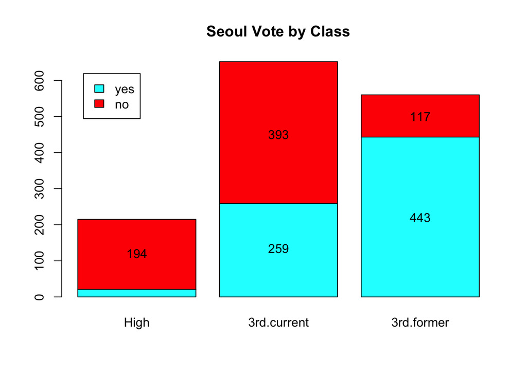

```r
# barplot(xtabs(counts~vote+class, data=sejong.poll.2[region=="Seoul",], drop=T), col=c("cyan", "red"))
barplot(seoul.class, col=c("cyan", "red"))
title(main="Seoul Vote by Class")
text(x=c(0.7, 1.9, 1.9, 3.1, 3.1), y=c(120, 450, 135, 500, 220), labels=c("194","393", "259", "117", "443"))
legend("topleft", inset=0.05, fill=c("cyan", "red"), legend=c("yes", "no"))
```

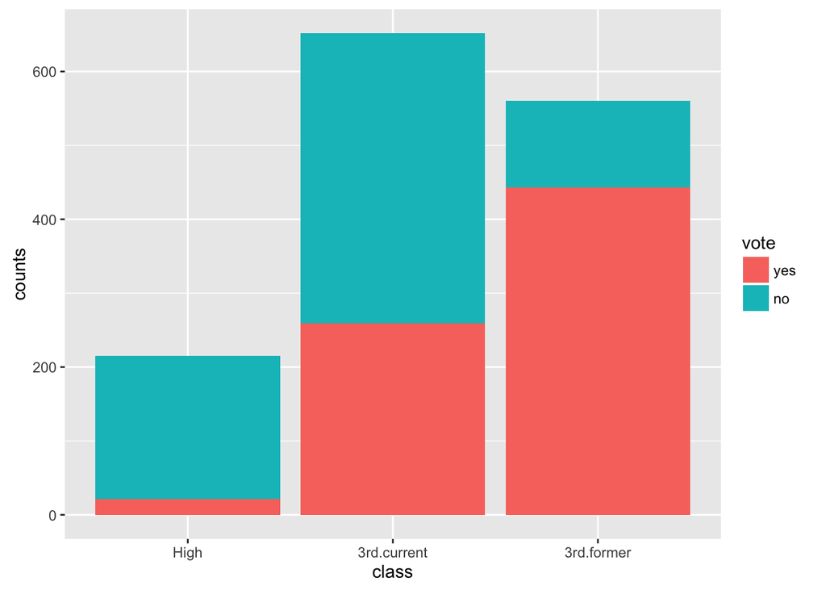

```r
library(ggplot2)
ggplot(sejong.poll.2.seoul, aes(x=class, y=counts, fill=vote)) +
  geom_bar(stat="identity")
```

- Using mosaicplot()

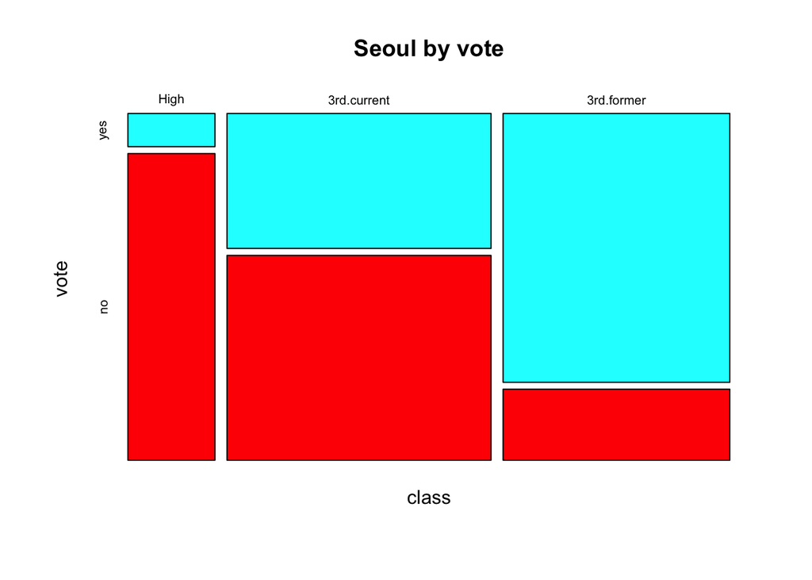

```r
mosaicplot(xtabs(counts~class+vote, data=sejong.poll.2[region=="Seoul",], drop=T), col=c("cyan", "red"), main="Seoul by vote")
```

- Draw barplot() for the Bureaus by region.

```r
(bureaus.region <- subset(sejong.poll.2.bureaus, !region=="Seoul"))
```

```
##    counts vote class      region color class.2
## 9      29  yes Chief     Gyunggi  cyan Bureaus
## 10      5   no Chief     Gyunggi   red Bureaus
## 13      1   no  High     Pyungan   red Bureaus
## 14      6  yes Chief     Pyungan  cyan Bureaus
## 15     35   no Chief     Pyungan   red Bureaus
## 18     17  yes Chief    Hwanghae  cyan Bureaus
## 19     17   no Chief    Hwanghae   red Bureaus
## 22      2   no  High Chungcheong   red Bureaus
## 23     35  yes Chief Chungcheong  cyan Bureaus
## 24     26   no Chief Chungcheong   red Bureaus
## 27      5  yes Chief     Kangwon  cyan Bureaus
## 28     10   no Chief     Kangwon   red Bureaus
## 31      1   no  High      Hamgil   red Bureaus
## 32      3  yes Chief      Hamgil  cyan Bureaus
## 33     14   no Chief      Hamgil   red Bureaus
## 36     55  yes Chief   Gyungsang  cyan Bureaus
## 37     16   no Chief   Gyungsang   red Bureaus
## 40      2   no  High      Jeolla   red Bureaus
## 41     42  yes Chief      Jeolla  cyan Bureaus
## 42     12   no Chief      Jeolla   red Bureaus
```

```r
# xtabs(counts~vote+region, data=sejong.poll.2[class.2=="Bureaus" & !region=="Seoul",], drop=T)
# xtabs(counts ~ vote + region, data = bureaus.region, drop = TRUE)
(bureaus.region.tbl <- xtabs(counts ~ vote + region, data = bureaus.region, drop = TRUE))
```

```
##      region
## vote  Gyunggi Pyungan Hwanghae Chungcheong Kangwon Hamgil Gyungsang Jeolla
##   yes      29       6       17          35       5      3        55     42
##   no        5      36       17          28      10     15        16     14
```

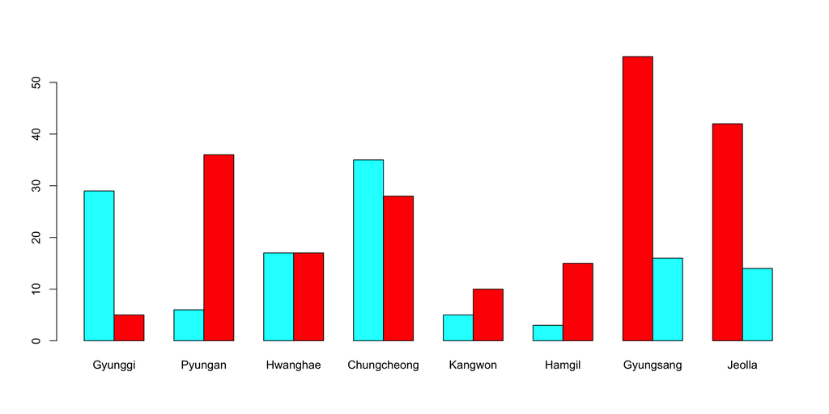

```r
barplot(bureaus.region.tbl, beside = TRUE, col=color)
```

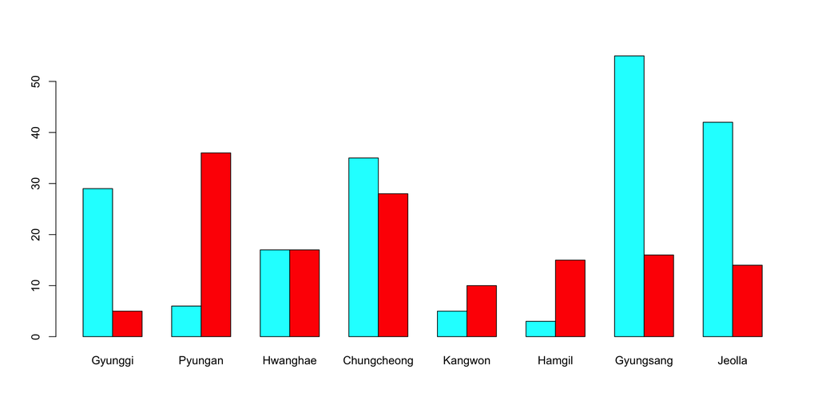

```r
barplot(bureaus.region.tbl, beside = TRUE, col=c("cyan", "red"))
```

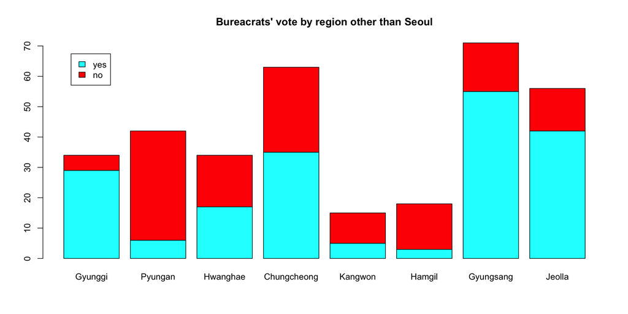

```r
barplot(bureaus.region.tbl, col=c("cyan", "red"))
title(main="Bureacrats' vote by region other than Seoul")
legend("topleft", inset=0.05, fill=c("cyan", "red"), legend=c("yes", "no"))
```

```r
(bureaus.region.df <- as.data.frame(bureaus.region.tbl))
```

```
##    vote      region Freq
## 1   yes     Gyunggi   29
## 2    no     Gyunggi    5
## 3   yes     Pyungan    6
## 4    no     Pyungan   36
## 5   yes    Hwanghae   17
## 6    no    Hwanghae   17
## 7   yes Chungcheong   35
## 8    no Chungcheong   28
## 9   yes     Kangwon    5
## 10   no     Kangwon   10
## 11  yes      Hamgil    3
## 12   no      Hamgil   15
## 13  yes   Gyungsang   55
## 14   no   Gyungsang   16
## 15  yes      Jeolla   42
## 16   no      Jeolla   14
```

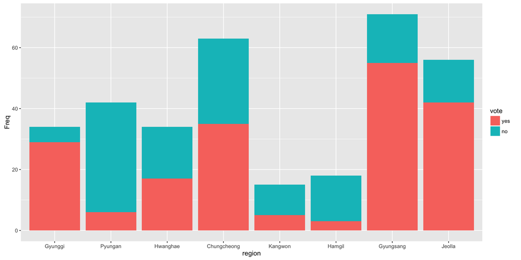

```r
ggplot(bureaus.region.df, aes(x=region, y=Freq, fill=vote)) +
  geom_bar(stat="identity")
```

- Using mosaicplot()

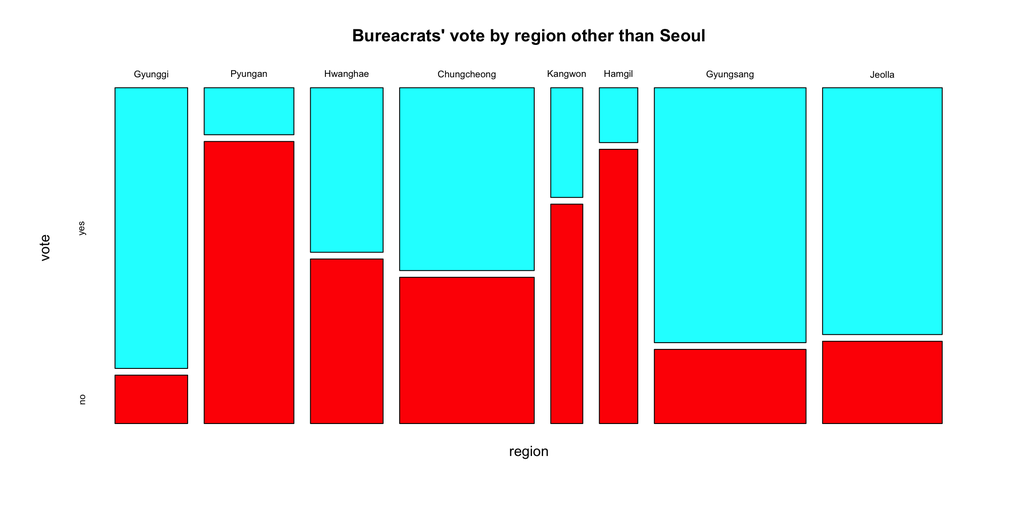

```r
mosaicplot(xtabs(counts~region+vote, data=sejong.poll.2[class.2=="Bureaus" & !region=="Seoul",], drop=T), col=c("cyan", "red"), main="")
title(main="Bureacrats' vote by region other than Seoul")
```

- Draw barplot() for the Commons by region.

```r
(commons.region.tbl <- xtabs(counts ~ vote + region, data = sejong.poll.2.commons, drop = TRUE))
```

```
##      region
## vote   Yuhu Gyunggi Pyungan Hwanghae Chungcheong Kangwon Hamgil Gyungsang
##   yes  1123   17076    1326     4454        6982     939     75     36262
##   no     71     236   28474    15601       14013    6888   7387       377
##      region
## vote  Jeolla
##   yes  29505
##   no     257
```

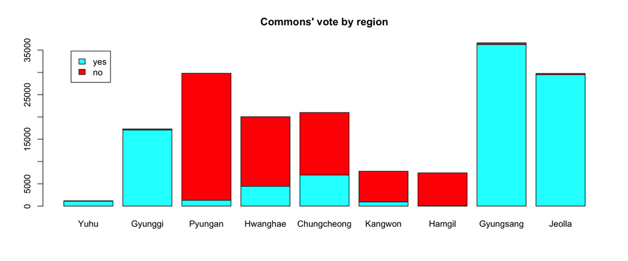

```r
barplot(commons.region.tbl, col=c("cyan", "red"))
# xtabs(counts~vote+region, data=sejong.poll.2[class.2=="Commons",], drop=T)
# barplot(xtabs(counts~vote+region, data=sejong.poll.2[class.2=="Commons",], drop=T), col=c("cyan", "red"))
title(main="Commons' vote by region")
legend("topleft", inset=0.05, fill=c("cyan", "red"), legend=c("yes", "no"))
```

```r
(commons.region.df <- as.data.frame(commons.region.tbl))
```

```
##    vote      region  Freq
## 1   yes        Yuhu  1123
## 2    no        Yuhu    71
## 3   yes     Gyunggi 17076
## 4    no     Gyunggi   236
## 5   yes     Pyungan  1326
## 6    no     Pyungan 28474
## 7   yes    Hwanghae  4454
## 8    no    Hwanghae 15601
## 9   yes Chungcheong  6982
## 10   no Chungcheong 14013
## 11  yes     Kangwon   939
## 12   no     Kangwon  6888
## 13  yes      Hamgil    75
## 14   no      Hamgil  7387
## 15  yes   Gyungsang 36262
## 16   no   Gyungsang   377
## 17  yes      Jeolla 29505
## 18   no      Jeolla   257
```

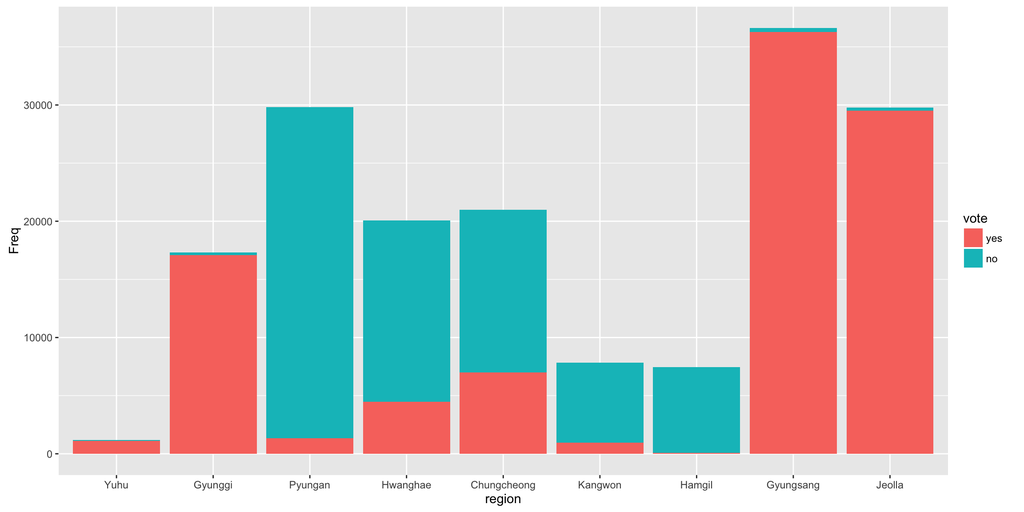

```r
ggplot(commons.region.df, aes(x=region, y=Freq, fill=vote)) +
  geom_bar(stat="identity")
```

- Draw by mosaicplot() in base graphics.

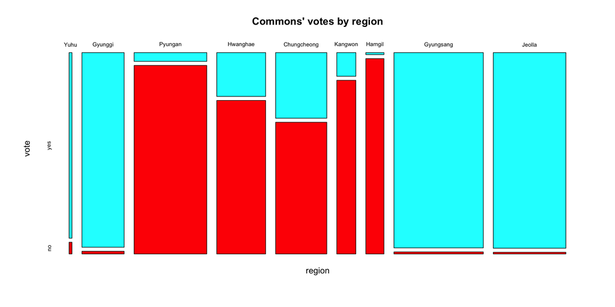

```r
mosaicplot(xtabs(counts~region+vote, data=sejong.poll.2[class.2=="Commons",], drop=T), col=c("cyan", "red"), main="Commons' votes by region")
```

- Chungcheong’s case.

```r
xtabs(counts~vote+class, data=sejong.poll.2[region=="Chungcheong",], drop=T)
```

```
##      class
## vote   High Chief Commons
##   yes     0    35    6982
##   no      2    26   14013
```

```r
prop.table(xtabs(counts~vote+class, data=sejong.poll.2[region=="Chungcheong",], drop=T), margin=2)
```

```
##      class
## vote   High Chief Commons
##   yes 0.000 0.574   0.333
##   no  1.000 0.426   0.667
```

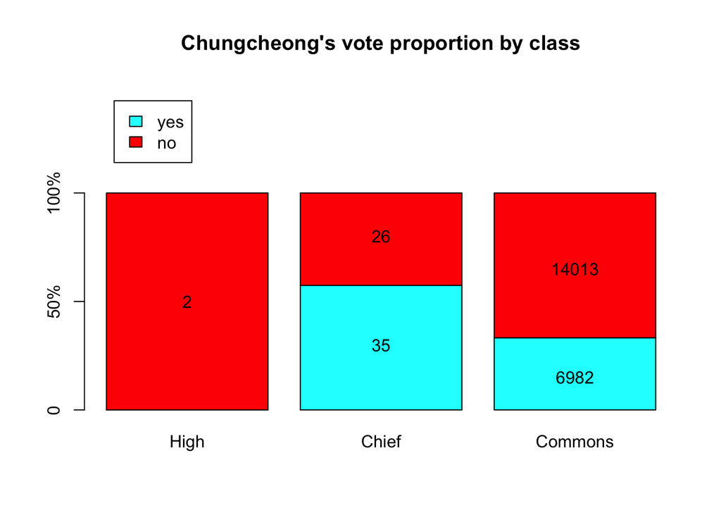

```r
barplot(prop.table(xtabs(counts~vote+class, data=sejong.poll.2[region=="Chungcheong",], drop=T), margin=2), col=c("cyan", "red"), ylim=c(0, 1.5), axes=F)
axis(side=2, at=c(0, 0.5, 1.0), labels=c("0", "50%", "100%"))
title(main="Chungcheong's vote proportion by class")
legend("topleft", inset=0.05, fill=c("cyan", "red"), legend=c("yes", "no"))
text(x=c(0.7, 1.9, 1.9, 3.1, 3.1), y=c(0.5, 0.3, 0.8, 0.15, 0.65), labels=c(2, 35, 26, 6982, 14013))
```

- With mosaicplot, it’s hard to compare.

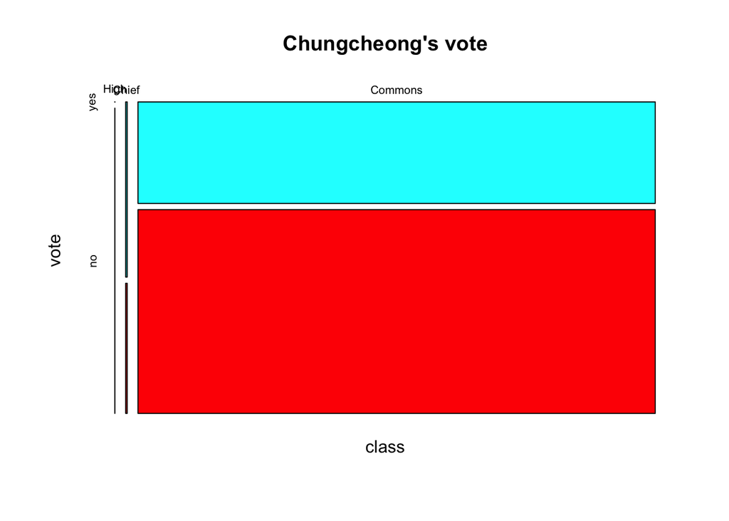

```r
mosaicplot(xtabs(counts~class+vote, data=sejong.poll.2[region=="Chungcheong",], drop=T), col=c("cyan", "red"), main="")
title(main="Chungcheong's vote")
```

- Save the working directory image, save history and quit.

```r
save.image(file="sejong_poll0328_gg.rda")
# savehistory(file="sejong_poll0328_gg.Rhistory")
```